# Introduction to Econometrics with R

M. Arnold, M. Schmelzer, A. Gerber

2016-06-07

# Chapter 3

## Section 3.5

### Table 3.1 - Not completed (sig. test)

```r
library(dplyr, quietly=T)
# Read in CPS data (taken from http:// ....)
cps_dat <- read.csv("data/cps_ch3.csv", sep=";", dec=".")
# Get an overview of the data structure
head(cps_dat)
```

```
##   a_sex year    ahe12
## 1     1 1992 18.30969
## 2     1 1992 16.36428
## 3     1 1992 24.47649
## 4     2 1992 14.17163
## 5     1 1992 23.60233
## 6     2 1992 12.98128
```

```r
# Take cps_dat %>% group data by gender and year %>% compute the mean, standard deviation
# and number of observations for each group
avgs <- cps_dat %>% group_by(a_sex, year) %>% summarise(mean(ahe12), sd(ahe12), n())
print(avgs, digits=2)
```

```
## Source: local data frame [12 x 5]
## Groups: a_sex [?]
##
##    a_sex  year mean(ahe12) sd(ahe12)   n()
##    (int) (int)       (dbl)     (dbl) (int)
## 1      1  1992    24.83019 10.852310  1594
## 2      1  1996    23.97028 10.794585  1380
## 3      1  2000    26.54988 12.376707  1303
## 4      1  2004    26.80202 12.811654  1894
## 5      1  2008    26.63023 12.573526  1839
## 6      1  2012    25.29886 12.091118  2004
## 7      2  1992    21.38683  8.394597  1368
## 8      2  1996    20.25632  8.486105  1230
## 9      2  2000    22.12856  9.986240  1181
## 10     2  2004    22.42996  9.989347  1735
## 11     2  2008    22.26640 10.300938  1871
## 12     2  2012    21.50238  9.986548  1951
```

Now that we have the numbers we can compute the difference between both genders.

```r
male   <- avgs %>% filter(a_sex == 1)
female <- avgs %>% filter(a_sex == 2)
colnames(male)   <- c("Sex", "Year", "Y_bar_m", "s_m", "n_m")
colnames(female) <- c("Sex", "Year", "Y_bar_f", "s_f", "n_f")

# Gender gap, standard errors and confidence intervals
gap      <- male$Y_bar_m - female$Y_bar_f
gap_se   <- sqrt(male$s_m^2 / male$n_m + female$s_f^2 / female$n_f)
gap_ci_l <- gap - 1.96 * gap_se
gap_ci_u <- gap + 1.96 * gap_se
result <- cbind(male[,-1], female[,-(1:2)], gap, gap_se, gap_ci_l, gap_ci_u)
print(result, digits = 2)
```

```
##   Year Y_bar_m s_m  n_m Y_bar_f  s_f  n_f gap gap_se gap_ci_l gap_ci_u
## 1 1992      25  11 1594      21  8.4 1368 3.4   0.35      2.7      4.1
## 2 1996      24  11 1380      20  8.5 1230 3.7   0.38      3.0      4.5
## 3 2000      27  12 1303      22 10.0 1181 4.4   0.45      3.5      5.3
## 4 2004      27  13 1894      22 10.0 1735 4.4   0.38      3.6      5.1
## 5 2008      27  13 1839      22 10.3 1871 4.4   0.38      3.6      5.1
## 6 2012      25  12 2004      22 10.0 1951 3.8   0.35      3.1      4.5
```

# Chapter 4

## Linear Regression with One Regressor

This chapter introduces the linear regression model which relates one variable, $X$, to another variable $Y$. If for example a school cuts the class sizes by hiring new teachers, would this have an impact on the students test scores? With linear regression we can not only examine whether the class size ($X$) does have an impact on the test results ($Y$). We can learn also something about the direction and the strength of the effect.

```r
library(AER)                                                    # contains the dataset
data(CASchools)

CASchools$tsratio  <- CASchools$students/CASchools$teachers     # teacher-student-ratio
CASchools$score    <- (CASchools$read + CASchools$math)/2       # average test-score
```

```r
mean(CASchools$tsratio)
```

```
## [1] 19.64043
```

```r
mean(CASchools$score)
```

```
## [1] 654.1565
```

```r
sd(CASchools$tsratio)
```

```
## [1] 1.891812
```

```r
sd(CASchools$score)
```

```
## [1] 19.05335
```

```r
quantiles          <- c(0.10, 0.25, 0.4, 0.5, 0.6, 0.75, 0.9)
quantile(CASchools$tsratio, quantiles)
```

```
##      10%      25%      40%      50%      60%      75%      90%
## 17.34860 18.58236 19.26618 19.72321 20.07830 20.87181 21.86741
```

```r
quantile(CASchools$score, quantiles)
```

```
##      10%      25%      40%      50%      60%      75%      90%
## 630.3950 640.0500 649.0700 654.4500 659.4000 666.6625 678.8600
```

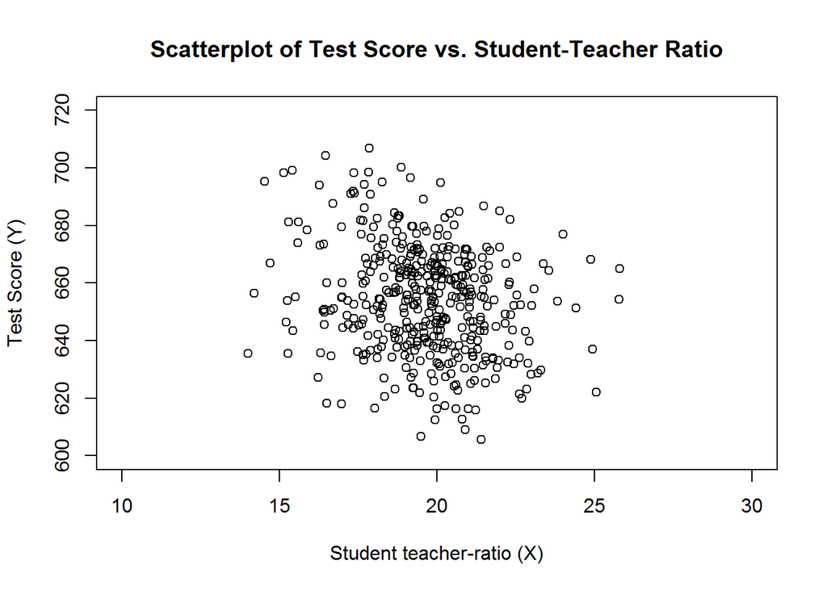

```r
plot(score ~ tsratio,
     data = CASchools,
     main = "Scatterplot of Test Score vs. Student-Teacher Ratio",
     xlab = "Student teacher-ratio (X)",
     ylab = "Test Score (Y)",
     xlim = c(10,30),
     ylim = c(600, 720))
```

## The Ordinary Least Squares Estimator (OLS)

```r
attach(CASchools)
beta_1 <- sum((tsratio - mean(tsratio))*(score - mean(score))) / sum((tsratio - mean(tsratio))^2)
beta_0 <- mean(score) - beta_1 * mean(tsratio)
```

```r
plot(score ~ tsratio,
     data = CASchools,
     main = "Scatterplot of Test Score vs. Student-Teacher Ratio",
     xlab = "Student teacher-ratio (X)",
     ylab = "Test Score (Y)",
     xlim = c(10,30),
     ylim = c(600, 720))

linear_model <- lm(score ~ tsratio, data = CASchools)
linear_model
```

```
##
## Call:
## lm(formula = score ~ tsratio, data = CASchools)
##
## Coefficients:
## (Intercept)      tsratio
##      698.93        -2.28
```

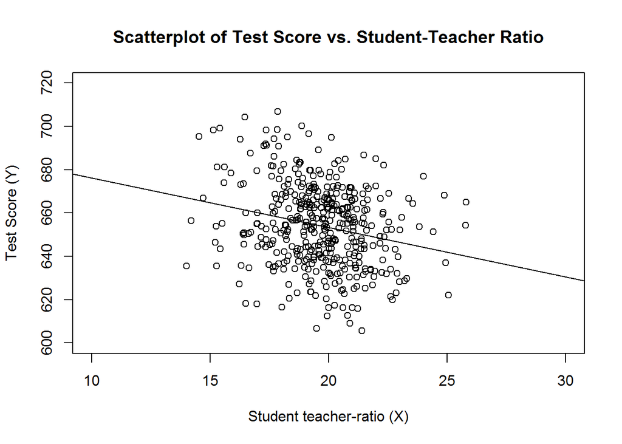

```r
abline(a = beta_0, b = beta_1)
```

```r
linear_model <- lm(score ~ tsratio, data = CASchools)
linear_model
```

```
##
## Call:
## lm(formula = score ~ tsratio, data = CASchools)
##
## Coefficients:
## (Intercept)      tsratio
##      698.93        -2.28
```

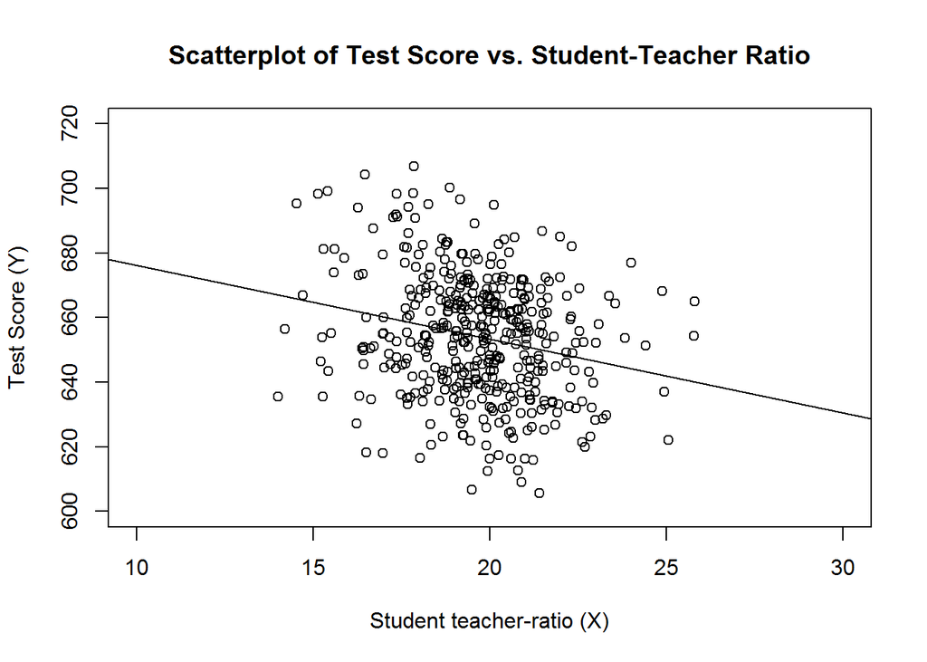

```r
plot(score ~ tsratio,
     data = CASchools,
     main = "Scatterplot of Test Score vs. Student-Teacher Ratio",
     xlab = "Student teacher-ratio (X)",
     ylab = "Test Score (Y)",
     xlim = c(10,30),
     ylim = c(600, 720))

abline(linear_model)
```

# Chapter 5

## Section 5.1

Consider again the previous OLS regression that gave us the regression line
$$\widehat{score} = 698.9 - 2.28 \times tsratio.$$
For testing a hypothesis regarding the slope parameter, we need $SE(\hat{\beta}_1)$, the standard error of the respective point estimator. By looking at the second column of the coefficient’s summary, we find this value to be approximately $0.48$.

```r
summary(linear_model)$coefficients
```

```
##               Estimate Std. Error   t value      Pr(>|t|)
## (Intercept) 698.932949  9.4674911 73.824516 6.569846e-242
## tsratio      -2.279808  0.4798255 -4.751327  2.783308e-06
```

How is $SE(\hat{\beta}_1)$ computed? The `summary` function uses the homoskedasticity-only formula
$$SE(\hat{\beta}_1) = \sqrt{ \overset{\sim}{\sigma}^2_{beta_1} } = \sqrt{ \frac{SER^2}{\sum(X_i - \overline{X})^2} }.$$

## Section 5.4

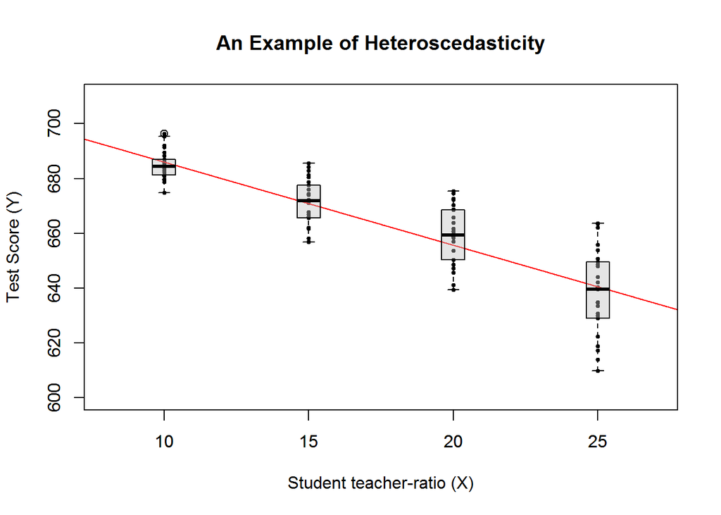

```r
library(scales)

# Genrate some heteroscedastic data

set.seed(123)
x <- rep(c(10,15,20,25),each=25)
e <- rnorm(100, sd=12)
i <- order(runif(100, max=dnorm(e, sd=12)))
y <- 720 - 3.3 * x + e[rev(i)]

# Plot data and inspect conditional distributions

mod <- lm(y ~ x)
plot(x, y, main="An Example of Heteroscedasticity",
     xlab = "Student teacher-ratio (X)",
     ylab = "Test Score (Y)",
     cex=0.5, pch=19, xlim=c(8,27), ylim=c(600,710))
abline(mod, col="red")
boxplot(y~x, add=TRUE, at=c(10,15,20,25), col=alpha("gray", 0.4), border="black")
```

```r
#if(!require(devtools))
#  install.packages("devtools")
#library(devtools)
#install_github("datacamp/tutorial")
#library(tutorial)
```

We already have assigned the model’s summary to `mod`. Now, use your R knowledge to display coefficients and standard errors!

# Chapter 6

## Section 6.3

```r
# Multiple Regression - Application to Test Scores and the Student-Teacher Ratio
library(AER)                                                    # contains the dataset
data(CASchools)
CASchools$tsratio  <- CASchools$students/CASchools$teachers     # teacher-student-ratio
CASchools$score    <- (CASchools$read + CASchools$math)/2       # average test-score
model <- lm(score ~ tsratio + english, data = CASchools)
```

## Section 6.4

Taking the code from Section 6.3 you could simply use `summary(model)` to print the $SER$, $R^2$ and adjusted-$R^2$. You find them at the bottom of the output.

```r
summary(model)
```

```
##
## Call:
## lm(formula = score ~ tsratio + english, data = CASchools)
##
## Residuals:
##     Min      1Q  Median      3Q     Max
## -48.845 -10.240  -0.308   9.815  43.461
##
## Coefficients:
##              Estimate Std. Error t value Pr(>|t|)
## (Intercept) 686.03224    7.41131  92.566  < 2e-16 ***
## tsratio      -1.10130    0.38028  -2.896  0.00398 **
## english      -0.64978    0.03934 -16.516  < 2e-16 ***
## ---
## Signif. codes:  0 '***' 0.001 '**' 0.01 '*' 0.05 '.' 0.1 ' ' 1
##
## Residual standard error: 14.46 on 417 degrees of freedom
## Multiple R-squared:  0.4264, Adjusted R-squared:  0.4237
## F-statistic:   155 on 2 and 417 DF,  p-value: < 2.2e-16
```

You can also compute the parameters by hand using the formulas on p. 242.

```r
n <- nrow(CASchools)    # number of observations (rows)
k <- 2                  # 2 regressors
y_mean <- mean(CASchools$score)

SSR <- sum( residuals(model)^2 )
TSS <- sum( ( CASchools$score - y_mean )^2 )
ESS <- sum((fitted(model) - y_mean)^2)

SER <- sqrt(1/(n-k-1) * SSR)
Rsq <- 1 - (SSR / TSS)
adj_Rsq <- 1 - (n-1)/(n-k-1) * SSR/TSS
cat(SER, Rsq, adj_Rsq, sep = "    ")
```

```
## 14.46448    0.4264315    0.4236805
```

## Section 6.7

### Examples of Perfect Multicollinearity

If you try to compute OLS with a set of regressors that suffer from perfect multicollinearity the system will warn you and ignore the regressor(s) which is(are) assumed to be a linear combination of the others.

```r
# Example 1
library(AER)                                                    # contains the dataset
data(CASchools)
CASchools$tsratio  <- CASchools$students/CASchools$teachers     # teacher-student-ratio
CASchools$score    <- (CASchools$read + CASchools$math)/2       # average test-score
CASchools$FracEL    <- CASchools$english/100
model <- lm(score ~ tsratio + english + FracEL, data = CASchools)
summary(model)
```

```
##
## Call:
## lm(formula = score ~ tsratio + english + FracEL, data = CASchools)
##
## Residuals:
##     Min      1Q  Median      3Q     Max
## -48.845 -10.240  -0.308   9.815  43.461
##
## Coefficients: (1 not defined because of singularities)
##              Estimate Std. Error t value Pr(>|t|)
## (Intercept) 686.03224    7.41131  92.566  < 2e-16 ***
## tsratio      -1.10130    0.38028  -2.896  0.00398 **
## english      -0.64978    0.03934 -16.516  < 2e-16 ***
## FracEL             NA         NA      NA       NA
## ---
## Signif. codes:  0 '***' 0.001 '**' 0.01 '*' 0.05 '.' 0.1 ' ' 1
##
## Residual standard error: 14.46 on 417 degrees of freedom
## Multiple R-squared:  0.4264, Adjusted R-squared:  0.4237
## F-statistic:   155 on 2 and 417 DF,  p-value: < 2.2e-16
```

```r
# Example 2
library(AER)                                                    # contains the dataset
data(CASchools)
CASchools$tsratio  <- CASchools$students/CASchools$teachers     # teacher-student-ratio
CASchools$score    <- (CASchools$read + CASchools$math)/2       # average test-score
CASchools$NVS      <- ifelse(CASchools$tsratio < 12, 0, 1)      # If tsration smaller 12, NVS = 0, else NVS = 1
model <- lm(score ~ tsratio + english + NVS, data = CASchools)
summary(model)
```

```
##
## Call:
## lm(formula = score ~ tsratio + english + NVS, data = CASchools)
##
## Residuals:
##     Min      1Q  Median      3Q     Max
## -48.845 -10.240  -0.308   9.815  43.461
##
## Coefficients: (1 not defined because of singularities)
##              Estimate Std. Error t value Pr(>|t|)
## (Intercept) 686.03224    7.41131  92.566  < 2e-16 ***
## tsratio      -1.10130    0.38028  -2.896  0.00398 **
## english      -0.64978    0.03934 -16.516  < 2e-16 ***
## NVS                NA         NA      NA       NA
## ---
## Signif. codes:  0 '***' 0.001 '**' 0.01 '*' 0.05 '.' 0.1 ' ' 1
##
## Residual standard error: 14.46 on 417 degrees of freedom
## Multiple R-squared:  0.4264, Adjusted R-squared:  0.4237
## F-statistic:   155 on 2 and 417 DF,  p-value: < 2.2e-16
```

```r
# Example 3
library(AER)                                                    # contains the dataset
data(CASchools)
CASchools$tsratio  <- CASchools$students/CASchools$teachers  # teacher-student-ratio
CASchools$score    <- (CASchools$read + CASchools$math)/2  # average test-score
CASchools$PctES    <- 100 - CASchools$english  # Percentage of english speakers
model <- lm(score ~ tsratio + english + PctES, data = CASchools)
summary(model)
```

```
##
## Call:
## lm(formula = score ~ tsratio + english + PctES, data = CASchools)
##
## Residuals:
##     Min      1Q  Median      3Q     Max
## -48.845 -10.240  -0.308   9.815  43.461
##
## Coefficients: (1 not defined because of singularities)
##              Estimate Std. Error t value Pr(>|t|)
## (Intercept) 686.03224    7.41131  92.566  < 2e-16 ***
## tsratio      -1.10130    0.38028  -2.896  0.00398 **
## english      -0.64978    0.03934 -16.516  < 2e-16 ***
## PctES              NA         NA      NA       NA
## ---
## Signif. codes:  0 '***' 0.001 '**' 0.01 '*' 0.05 '.' 0.1 ' ' 1
##
## Residual standard error: 14.46 on 417 degrees of freedom
## Multiple R-squared:  0.4264, Adjusted R-squared:  0.4237
## F-statistic:   155 on 2 and 417 DF,  p-value: < 2.2e-16
```